# Statistical description of iris data

Bryan Tchakote

12/12/2020

# 1 Description of the data set

```r
?iris
```

```
## starting httpd help server ... done
```

According to the help, **iris** data set gives the measurements in centimeters of the variables **sepal length and width and petal** **length and width**, respectively, for 50 flowers from each of 3 species of iris. The species are **Iris setosa, versicolor, and** **virginica**.

```r
dim(iris)
```

```
## [1] 150   5
```

```r
colnames(iris)
```

```
## [1] "Sepal.Length" "Sepal.Width"  "Petal.Length" "Petal.Width"  "Species"
```

**iris** is a data set of 150 rows (observations) and 5 columns (variables) which are:

- Sepal.Length
- Sepal.Width
- Petal.Length
- Petal.Width
- Species

# 2 Univariate analysis

- Personnalized fonctions used for the univariate analysis

```r
numeric_summary = function(current_col){
  current_col_summary = c()

  assign_and_name = function(fun, name){
    x = fun
    names(x) = name
    current_col_summary = append(current_col_summary, x)
    return (current_col_summary)
  }

  # Measures of central location
  current_col_summary = assign_and_name(as.vector(summary(current_col)),
  names(summary(current_col)))


  # Measures of dispersion

  ## Range and Interquartile range
  current_col_summary = assign_and_name(current_col_summary[6] - current_col_summary[1],
  "Range")

  current_col_summary = assign_and_name(current_col_summary[5] - current_col_summary[2],
  "Interquartile range")

  ## Variance & Standard deviation
  current_col_summary = assign_and_name((var(current_col)*(length(current_col) - 1)) /
  length(current_col), "Variance")

  current_col_summary = assign_and_name(sd(current_col), "Standard deviation")


  # Skewness & Kurtosis
  current_col_summary = assign_and_name(skewness(current_col), "Skewness (Fisher)")
  current_col_summary = assign_and_name(kurtosis(current_col) - 3, "Kurtosis (Fisher)")

  current_col_summary = data.frame(current_col_summary)
  names(current_col_summary) = colnames(current_col)

  return (current_col_summary)
}

sk_and_kt_comments = function(sk, kt){
  if (sk < 0 ) {
    sk_c = "The distribution is negatively skewed, the mass of the
    distribution is concentrated on the right of the mean value.\n\n"
  } else if (sk > 0) {
    sk_c = "The distribution is positively skewed, the mass of the
    distribution is concentrated on the left of the mean value.\n\n"
  } else {
    sk_c = "The values are evenly distributed on both sides of the mean.\n\n"
  }

  if (kt < 0) {
    kt_c = "The distribution is platykurtic, according to the negative value of the
    kurtosis"
  } else if (kt > 0) {
    kt_c = "The distribution is leptokurtic, according to the positive value of
    the kurtosis"
  } else {
    kt_c = "The distribution is mesokurtic, the kurtosis value is zero"
  }

  return (c("Comment on the skewness\n", sk_c, "Comment on the kurtosis\n", kt_c))
}

graphic_summary = function(current_col){
  par(mfrow = c(1, 2))

  plot(table(current_col), xlab = colnames(current_col), ylab = "Occurences",
  col = "lightblue")

  boxplot(current_col, ylab = colnames(current_col), col = "lightblue",
  border = "darkgreen")

  par(mfrow = c(1, 1))

  plot(ecdf(current_col), main = colnames(current_col), col = "darkgreen")
}
```

## 2.1 Sepal.Length

### 2.1.1 Numeric summary

```r
S_L_summary = numeric_summary(iris[, 1])
S_L_summary
```

```
##
## Min.                 4.3000000
## 1st Qu.              5.1000000
## Median               5.8000000
## Mean                 5.8433333
## 3rd Qu.              6.4000000
## Max.                 7.9000000
## Range                3.6000000
## Interquartile range  1.3000000
## Variance             0.6811222
## Standard deviation   0.8280661
## Skewness (Fisher)    0.3117531
## Kurtosis (Fisher)   -0.5735679
```

**Comments (about the skewness and the kurtosis especially):**

```r
sk_and_kt_comments(S_L_summary[[11, 1]], S_L_summary[[12, 1]])
```

```
## [1] "Comment on the skewness\n"
## [2] "The distribution is positively skewed, the mass of the\n    distribution is concentrated on the left of the mean value.\n\n"
## [3] "Comment on the kurtosis\n"
## [4] "The distribution is platykurtic, according to the negative value of the\n    kurtosis"
```

### 2.1.2 Graphic summary

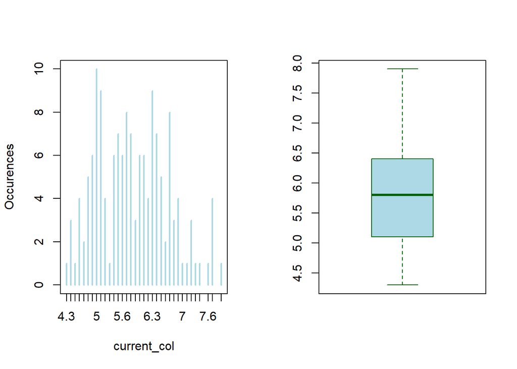

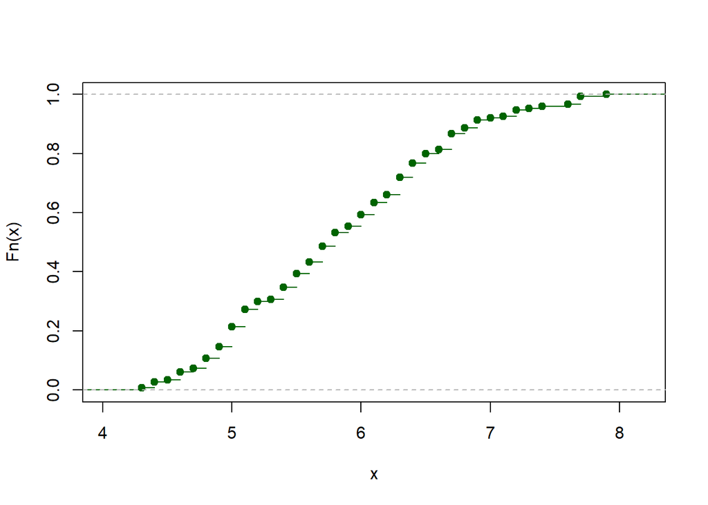

```r
graphic_summary(iris[, 1])
```

## 2.2 Sepal.Width

### 2.2.1 Numeric summary

```r
S_W_summary = numeric_summary(iris[, 2])
S_W_summary
```

```
##
## Min.                2.0000000
## 1st Qu.             2.8000000
## Median              3.0000000
## Mean                3.0573333
## 3rd Qu.             3.3000000
## Max.                4.4000000
## Range               2.4000000
## Interquartile range 0.5000000
## Variance            0.1887129
## Standard deviation  0.4358663
## Skewness (Fisher)   0.3157671
## Kurtosis (Fisher)   0.1809763
```

**Comments (about the skewness and the kurtosis especially):**

```r
sk_and_kt_comments(S_W_summary[[11, 1]], S_W_summary[[12, 1]])
```

```
## [1] "Comment on the skewness\n"
## [2] "The distribution is positively skewed, the mass of the\n    distribution is concentrated on the left of the mean value.\n\n"
## [3] "Comment on the kurtosis\n"
## [4] "The distribution is leptokurtic, according to the positive value of\n    the kurtosis"
```

### 2.2.2 Graphic summary

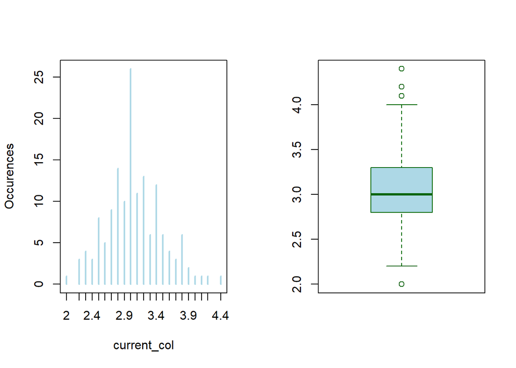

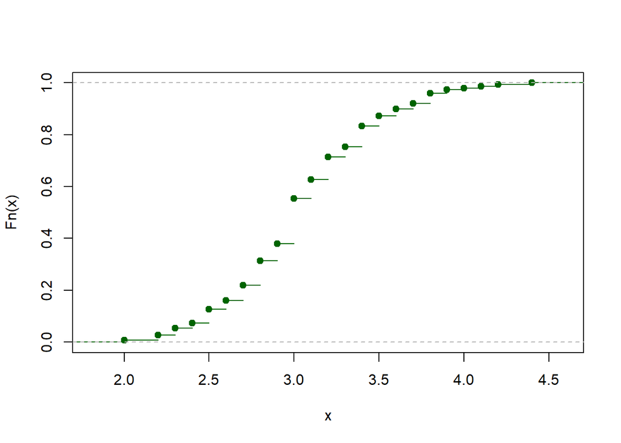

```r
graphic_summary(iris[, 2])
```

## 2.3 Petal.Length

### 2.3.1 Numeric summary

```r
P_L_summary = numeric_summary(iris[, 3])
P_L_summary
```

```
##
## Min.                 1.0000000
## 1st Qu.              1.6000000
## Median               4.3500000
## Mean                 3.7580000
## 3rd Qu.              5.1000000
## Max.                 6.9000000
## Range                5.9000000
## Interquartile range  3.5000000
## Variance             3.0955027
## Standard deviation   1.7652982
## Skewness (Fisher)   -0.2721277
## Kurtosis (Fisher)   -1.3955359
```

**Comments (about the skewness and the kurtosis especially):**

```r
sk_and_kt_comments(P_L_summary[[11, 1]], P_L_summary[[12, 1]])
```

```
## [1] "Comment on the skewness\n"
## [2] "The distribution is negatively skewed, the mass of the\n    distribution is concentrated on the right of the mean value.\n\n"
## [3] "Comment on the kurtosis\n"
## [4] "The distribution is platykurtic, according to the negative value of the\n    kurtosis"
```

### 2.3.2 Graphic summary

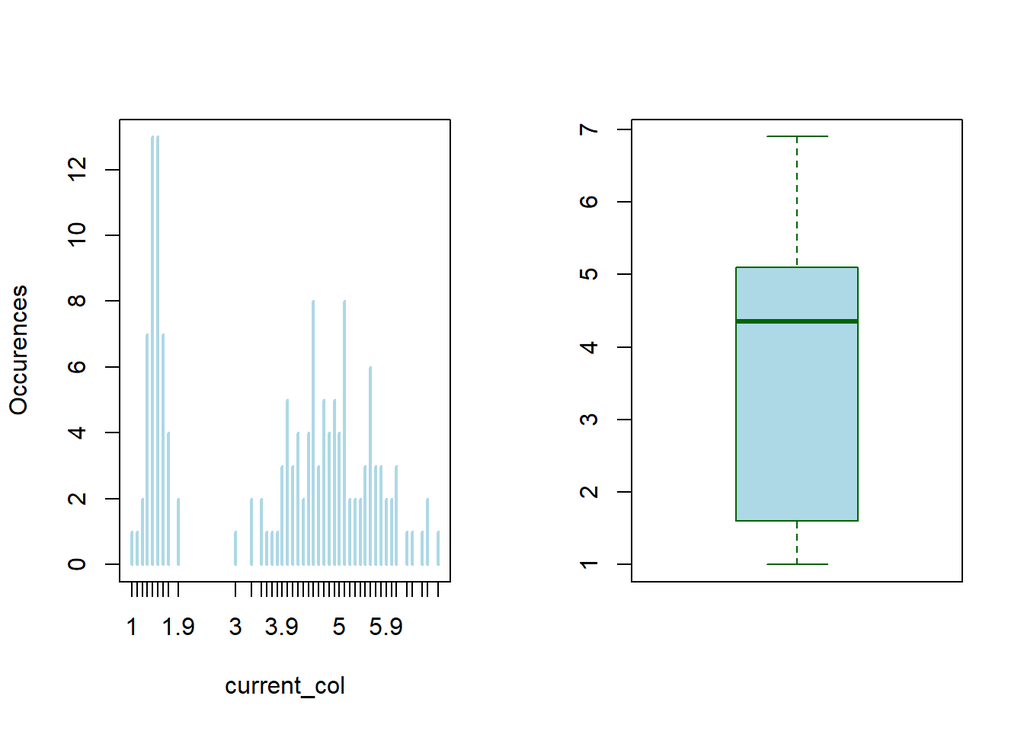

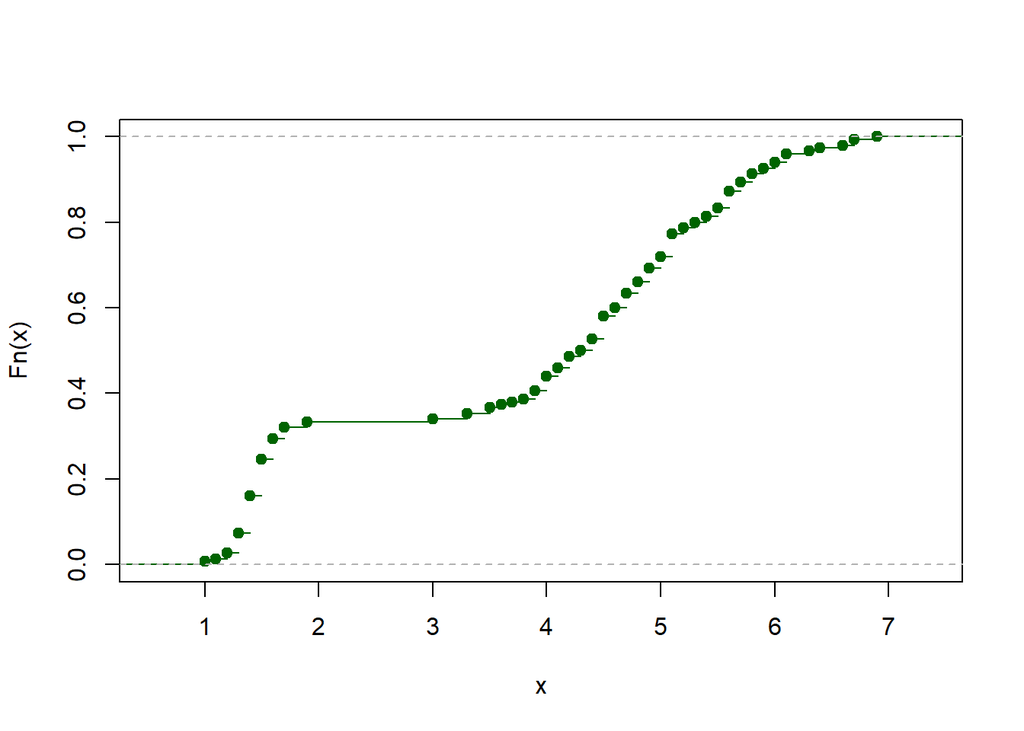

```r
graphic_summary(iris[, 3])
```

## 2.4 Petal.Width

### 2.4.1 Numeric summary

```r
P_W_summary = numeric_summary(iris[, 4])
P_W_summary
```

```
##
## Min.                 0.1000000
## 1st Qu.              0.3000000
## Median               1.3000000
## Mean                 1.1993333
## 3rd Qu.              1.8000000
## Max.                 2.5000000
## Range                2.4000000
## Interquartile range  1.5000000
## Variance             0.5771329
## Standard deviation   0.7622377
## Skewness (Fisher)   -0.1019342
## Kurtosis (Fisher)   -1.3360674
```

**Comments (about the skewness and the kurtosis especially):**

```r
sk_and_kt_comments(P_W_summary[[11, 1]], P_W_summary[[12, 1]])
```

```
## [1] "Comment on the skewness\n"
## [2] "The distribution is negatively skewed, the mass of the\n    distribution is concentrated on the right of the mean value.\n\n"
## [3] "Comment on the kurtosis\n"
## [4] "The distribution is platykurtic, according to the negative value of the\n    kurtosis"
```

### 2.4.2 Graphic summary

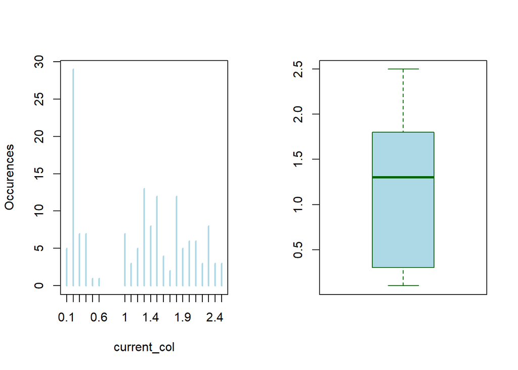

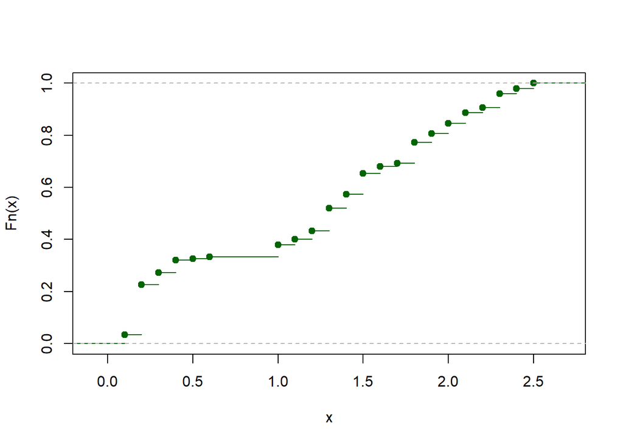

```r
graphic_summary(iris[, 4])
```

## 2.5 Species

```r
summary(iris$Species)
```

```
##     setosa versicolor  virginica
##         50         50         50
```

# 3 Bivariate analysis

## 3.1 Correlation between quantitatives variables

- Personnalized fonctions used for the bivariate analysis

```r
bivariate_analysis = function(col_X, col_Y){
  # Variables and respective marginal properties
  x_bar = mean(col_X)
  var_x = var(col_X) * ((length(col_X) - 1) / length(col_X))
  sd_x = sd(col_X)

  y_bar = mean(col_Y)
  sd_y = sd(col_Y)

  # Covariance
  cov_xy = cov(col_X, col_Y)

  # Correlation
  r_xy = cov_xy / (sd_x * sd_y)

  # Linear regression line (y = a + bx) - Coefficients a & b
  b = cov_xy / var_x
  a = y_bar - b*x_bar

  return (c(cov_xy, r_xy, a, b))
}

bivariate_graphs = function(X, Y, a, b){
  col_X = iris[, X]
  col_Y = iris[, Y]

  # Scatterplot
  plot(col_X, col_Y, col = "lightblue", pch = 20, xlab = names(iris)[X], ylab = names(iris)[Y],
  main = c("Scatterplot of", names(iris)[Y], "against", names(iris)[X]))

  # Linear regression line (actual line)
  abline(a, b, col = "darkgreen")
}
```

### 3.1.1 Sepal.Length & Sepal.Width

Let:

- **Sepal.Length** be the *explanatory variable* (X)
- **Sepal.Width** be the *outcome variable* (Y)

```r
SL_SW_bivariate_analysis = bivariate_analysis(iris$Sepal.Length, iris$Sepal.Width)
```

#### 3.1.1.1 Scatterplot

```r
# The scatterplot is going to be drawn lower, with the linear regression line
```

**Comment:** *A priori, the two variables seem to have a weak linear relationship. Let’s verify it by calculating joint properties.*

#### 3.1.1.2 Covariance & Correlation

- Covariance ($S_{xy}$)

```r
SL_SW_bivariate_analysis[1]
```

```
## [1] -0.042434
```

- Correlation coefficient ($r_{xy}$)

```r
SL_SW_bivariate_analysis[2]
```

```
## [1] -0.1175698
```

**Comment:** *As expected, this correlation coefficient close to zero shows that the linear link between ‘Sepal.Length’ and ‘Sepal.Width’ is very weak*

#### 3.1.1.3 Linear regression (y = a + bx)

```r
a = SL_SW_bivariate_analysis[3]
b = SL_SW_bivariate_analysis[4]

cat("Linear regression line equation:\ny =", a, "+", b, "x")
```

```
## Linear regression line equation:
## y = 3.421374 + -0.06230013 x
```

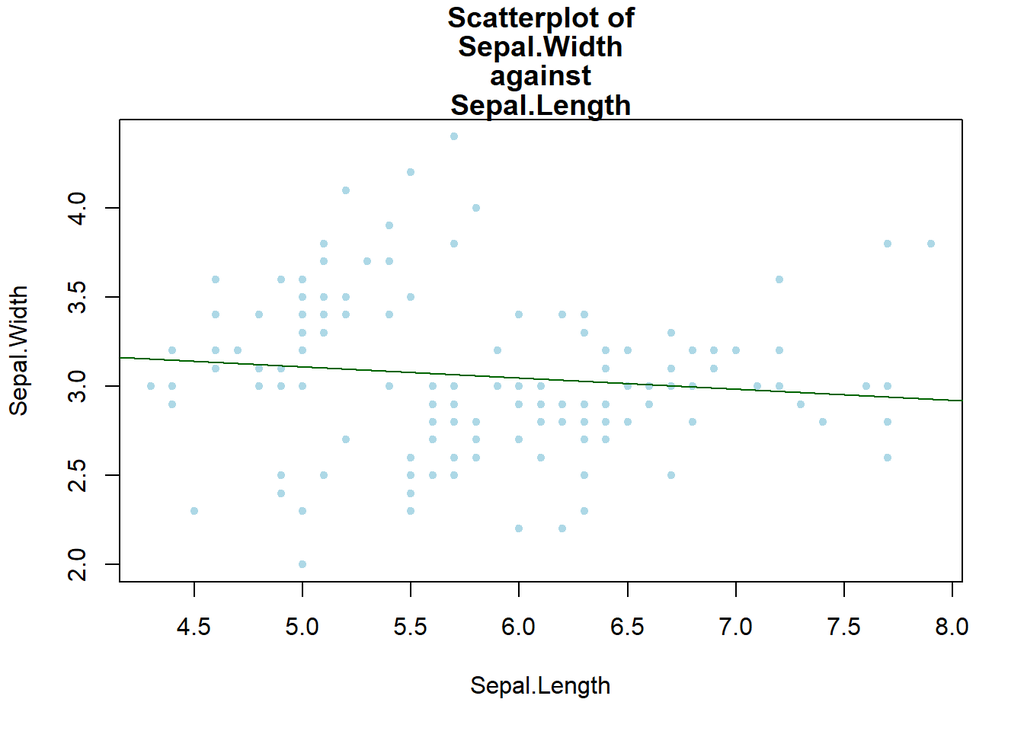

```r
bivariate_graphs(1, 2, a, b)
```